# Pemulusan

Megawati Roito Panjaitan

2023-09-02

## Library

```r
library(forecast)
```

```r
library(graphics)
library(TTR)
library(TSA)
library(rio)
```

## Impor data

```r
data<-import("https://raw.githubusercontent.com/panjaitanroito/Praktikum-MPDW/main/Data/data1.csv")
```

Deskripsi data: Dataset berisi perkiraan penjualan retail dan jasa makanan bulanan di AS menurut jenis usaha dari tahun 2000-2019. Data perkiraan ditampilkan di kolom “Value” dalam satuan juta dolar.

## Eksplorasi data

```r
View(data)
str(data)
```

```
## 'data.frame':    240 obs. of  2 variables:
##  $ Period: int  1 2 3 4 5 6 7 8 9 10 ...
##  $ Value : int  268044 272020 275192 271046 271394 273422 272630 272918 277548 276927 ...
```

```r
dim(data)
```

```
## [1] 240   2
```

```r
data.ts <- ts(data$Value)
summary(data.ts)
```

```
##    Min. 1st Qu.  Median    Mean 3rd Qu.    Max.
##  268044  329484  371578  381526  439710  525467
```

## Membuat plot semua data

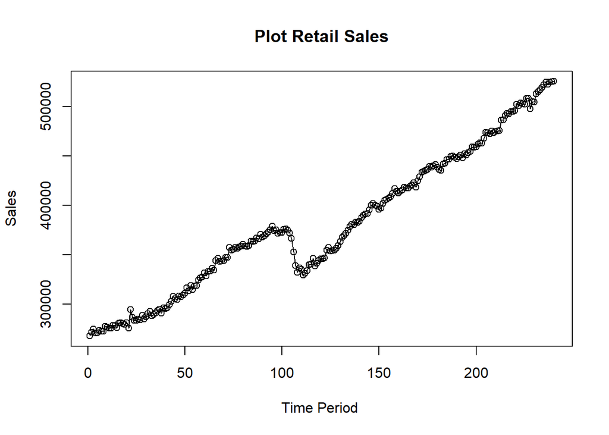

```r
ts.plot(data.ts, xlab="Time Period ", ylab="Sales",
        main = "Plot Retail Sales")
points(data.ts)
```

## Membagi data latih dan data uji

Data latih: 80% Data uji: 20%

```r
training_ma <- data[1:192,]
testing_ma <- data[193:240,]
train_ma.ts <- ts(training_ma$Value)
test_ma.ts <- ts(testing_ma$Value)
```

## Eksplorasi data

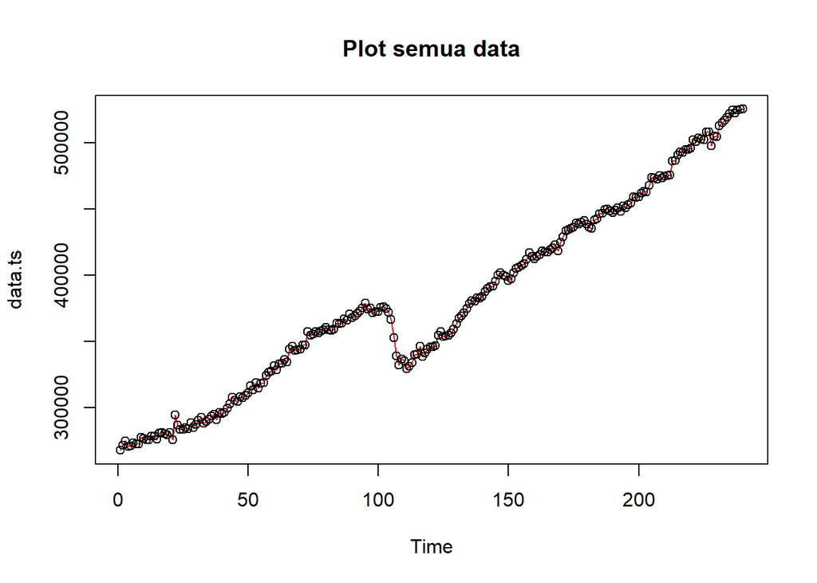

```r
#eksplorasi keseluruhan data
plot(data.ts, col="red",main="Plot semua data")
points(data.ts)
```

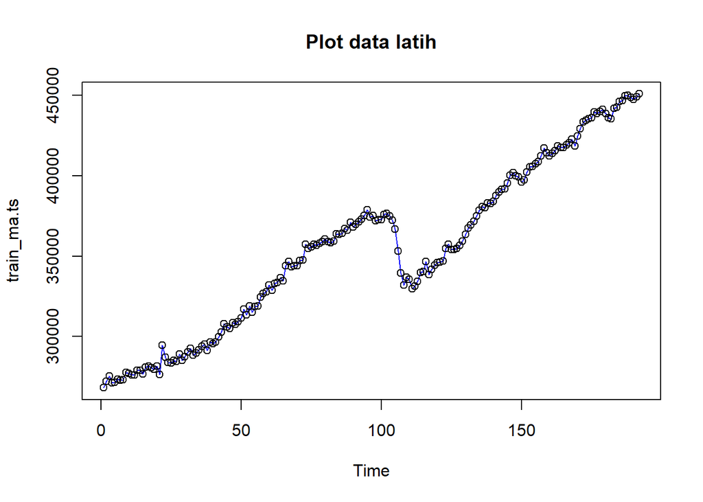

```r
#eksplorasi data latih
plot(train_ma.ts, col="blue",main="Plot data latih")
points(train_ma.ts)
```

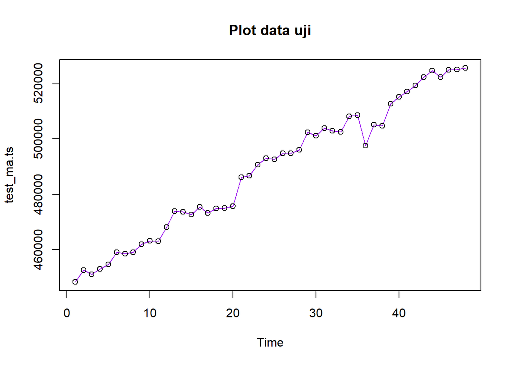

```r
#eksplorasi data uji
plot(test_ma.ts, col="purple",main="Plot data uji")
points(test_ma.ts)
```

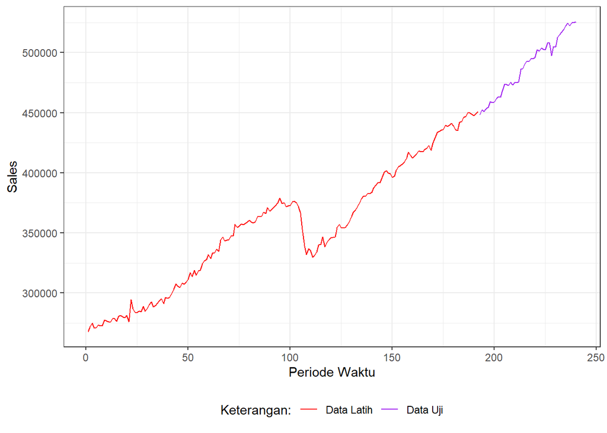

```r
#Eksplorasi dengan GGPLOT
library(ggplot2)
ggplot() +
  geom_line(data = training_ma, aes(x = Period, y = Value, col = "Data Latih")) +
  geom_line(data = testing_ma, aes(x = Period, y = Value, col = "Data Uji")) +
  labs(x = "Periode Waktu", y = "Sales", color = "Legend") +
  scale_colour_manual(name="Keterangan:", breaks = c("Data Latih", "Data Uji"),
                      values = c("red", "purple")) +
  theme_bw() + theme(legend.position = "bottom",
                     plot.caption = element_text(hjust=0.5, size=12))
```

# Pemulusan

## Single Moving Average (SMA)

```r
data.sma<-SMA(train_ma.ts, n=5)
data.sma
```

```
## Time Series:
## Start = 1
## End = 192
## Frequency = 1
##   [1]       NA       NA       NA       NA 271539.2 272614.8 272736.8 272282.0
##   [9] 273582.4 274689.0 275210.4 275842.6 277025.8 277270.8 277175.4 278131.2
##  [17] 279272.2 279585.6 279731.8 280724.4 279779.6 282388.4 283730.4 284570.6
##  [25] 284989.6 286783.6 284728.0 285072.4 285321.6 286094.4 287160.6 288838.2
##  [33] 288753.6 289678.6 290501.0 291213.4 291733.0 292284.4 293634.2 294457.4
##  [41] 294950.0 295825.6 298141.6 300438.4 302505.0 304184.8 305965.0 306897.0
##  [49] 307186.0 308278.0 310698.6 311695.6 314007.0 315147.8 316579.0 316992.0
##  [57] 319203.4 320758.6 323334.2 325999.2 327943.0 329634.4 331002.6 332752.0
##  [65] 333281.6 336342.0 339052.0 340997.2 342471.8 344386.8 345052.2 345218.0
##  [73] 348022.8 350172.8 352486.4 354506.0 356365.8 356475.4 357335.4 358340.6
##  [81] 358648.2 358999.8 359277.2 360222.0 360807.0 361816.0 363555.2 364939.4
##  [89] 366380.2 367287.8 368409.4 369249.4 370585.8 371456.8 373598.0 374534.8
##  [97] 375310.4 375103.2 374594.4 373336.8 373684.4 373928.2 374569.2 374477.0
## [105] 373308.4 368691.2 361270.2 352680.8 345609.8 339379.2 334738.6 333139.0
## [113] 333572.0 334162.8 335151.0 338535.2 339966.2 341445.8 342344.2 343455.2
## [121] 343359.4 345015.4 347606.2 350185.2 351773.8 353361.4 354919.8 355347.6
## [129] 355753.4 357654.8 360298.4 363232.4 366242.6 369394.0 372383.8 375069.4
## [137] 377276.0 379555.8 381102.6 382197.6 383584.8 385512.6 387191.0 389000.4
## [145] 391286.4 393790.2 396166.8 397832.0 399337.2 399490.0 398936.0 399005.6
## [153] 400095.8 401408.2 403696.2 405963.2 407980.4 410357.2 412015.6 412953.2
## [161] 414022.0 414702.8 414944.4 415610.4 416641.0 417668.8 418651.6 419537.2
## [169] 419732.6 421183.2 423154.8 425773.2 428066.2 431447.4 433740.0 435843.2
## [177] 436855.0 437962.6 439132.0 439664.6 438956.6 438283.2 438681.4 438946.0
## [185] 440427.2 442584.8 445470.2 447089.2 448317.0 448575.0 449043.8 449286.0
```

Forecast 1 periode ke depan:

```r
data.ramal<-c(NA,data.sma)
data.ramal
```

```
##   [1]       NA       NA       NA       NA       NA 271539.2 272614.8 272736.8
##   [9] 272282.0 273582.4 274689.0 275210.4 275842.6 277025.8 277270.8 277175.4
##  [17] 278131.2 279272.2 279585.6 279731.8 280724.4 279779.6 282388.4 283730.4
##  [25] 284570.6 284989.6 286783.6 284728.0 285072.4 285321.6 286094.4 287160.6
##  [33] 288838.2 288753.6 289678.6 290501.0 291213.4 291733.0 292284.4 293634.2
##  [41] 294457.4 294950.0 295825.6 298141.6 300438.4 302505.0 304184.8 305965.0
##  [49] 306897.0 307186.0 308278.0 310698.6 311695.6 314007.0 315147.8 316579.0
##  [57] 316992.0 319203.4 320758.6 323334.2 325999.2 327943.0 329634.4 331002.6
##  [65] 332752.0 333281.6 336342.0 339052.0 340997.2 342471.8 344386.8 345052.2
##  [73] 345218.0 348022.8 350172.8 352486.4 354506.0 356365.8 356475.4 357335.4
##  [81] 358340.6 358648.2 358999.8 359277.2 360222.0 360807.0 361816.0 363555.2
##  [89] 364939.4 366380.2 367287.8 368409.4 369249.4 370585.8 371456.8 373598.0
##  [97] 374534.8 375310.4 375103.2 374594.4 373336.8 373684.4 373928.2 374569.2
## [105] 374477.0 373308.4 368691.2 361270.2 352680.8 345609.8 339379.2 334738.6
## [113] 333139.0 333572.0 334162.8 335151.0 338535.2 339966.2 341445.8 342344.2
## [121] 343455.2 343359.4 345015.4 347606.2 350185.2 351773.8 353361.4 354919.8
## [129] 355347.6 355753.4 357654.8 360298.4 363232.4 366242.6 369394.0 372383.8
## [137] 375069.4 377276.0 379555.8 381102.6 382197.6 383584.8 385512.6 387191.0
## [145] 389000.4 391286.4 393790.2 396166.8 397832.0 399337.2 399490.0 398936.0
## [153] 399005.6 400095.8 401408.2 403696.2 405963.2 407980.4 410357.2 412015.6
## [161] 412953.2 414022.0 414702.8 414944.4 415610.4 416641.0 417668.8 418651.6
## [169] 419537.2 419732.6 421183.2 423154.8 425773.2 428066.2 431447.4 433740.0
## [177] 435843.2 436855.0 437962.6 439132.0 439664.6 438956.6 438283.2 438681.4
## [185] 438946.0 440427.2 442584.8 445470.2 447089.2 448317.0 448575.0 449043.8
## [193] 449286.0
```

Forecast 48 periode ke depan:

```r
data.gab<-cbind(aktual=c(train_ma.ts,rep(NA,48)),pemulusan=c(data.sma,rep(NA,48)),ramalan=c(data.ramal,rep(data.ramal[length(data.ramal)],47)))
data.gab
```

```
##        aktual pemulusan  ramalan
##   [1,] 268044        NA       NA
##   [2,] 272020        NA       NA
##   [3,] 275192        NA       NA
##   [4,] 271046        NA       NA
##   [5,] 271394  271539.2       NA
##   [6,] 273422  272614.8 271539.2
##   [7,] 272630  272736.8 272614.8
##   [8,] 272918  272282.0 272736.8
##   [9,] 277548  273582.4 272282.0
##  [10,] 276927  274689.0 273582.4
##  [11,] 276029  275210.4 274689.0
##  [12,] 275791  275842.6 275210.4
##  [13,] 278834  277025.8 275842.6
##  [14,] 278773  277270.8 277025.8
```

[output cut: 226 more lines]

### Visualisasi hasil pemulusan SMA

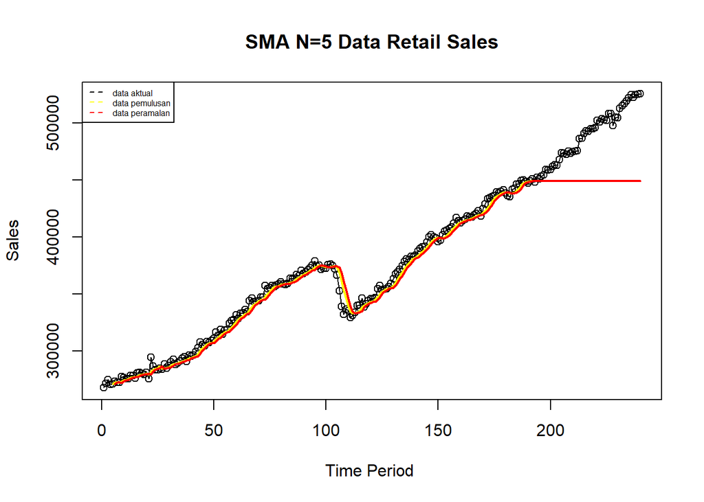

```r
ts.plot(data.ts, xlab="Time Period ", ylab="Sales", main= "SMA N=5 Data Retail Sales")
points(data.ts)
lines(data.gab[,2],col="yellow",lwd=2)
lines(data.gab[,3],col="red",lwd=2)
legend("topleft",c("data aktual","data pemulusan","data peramalan"), lty=8, col=c("black","yellow","red"), cex=0.5)
```

### I. Menghitung nilai keakuratan data latih

```r
error_train.sma = train_ma.ts-data.ramal[1:length(train_ma.ts)]
SSE_train.sma = sum(error_train.sma[6:length(train_ma.ts)]^2)
MSE_train.sma = mean(error_train.sma[6:length(train_ma.ts)]^2)
MAPE_train.sma = mean(abs((error_train.sma[6:length(train_ma.ts)]/train_ma.ts[6:length(train_ma.ts)])*100))

akurasi_train.sma <- matrix(c(SSE_train.sma, MSE_train.sma, MAPE_train.sma))
row.names(akurasi_train.sma)<- c("SSE", "MSE", "MAPE")
colnames(akurasi_train.sma) <- c("Akurasi m = 5")
akurasi_train.sma
```

```
##      Akurasi m = 5
## SSE   7.075443e+09
## MSE   3.783660e+07
## MAPE  1.286701e+00
```

Dalam hal ini nilai MAPE data latih pada metode pemulusan SMA kurang dari 2%, nilai ini dapat dikategorikan sebagai nilai akurasi yang sangat baik.

### II. Menghitung nilai keakuratan data uji

```r
error_test.sma = test_ma.ts-data.gab[193:240,3]
SSE_test.sma = sum(error_test.sma^2)
MSE_test.sma = mean(error_test.sma^2)
MAPE_test.sma = mean(abs((error_test.sma/test_ma.ts*100)))

akurasi_test.sma <- matrix(c(SSE_test.sma, MSE_test.sma, MAPE_test.sma))
row.names(akurasi_test.sma)<- c("SSE", "MSE", "MAPE")
colnames(akurasi_test.sma) <- c("Akurasi m = 5")
akurasi_test.sma
```

```
##      Akurasi m = 5
## SSE   1.017916e+11
## MSE   2.120658e+09
## MAPE  7.891798e+00
```

Perhitungan akurasi menggunakan data uji menghasilkan nilai MAPE yang kurang dari 10% sehingga nilai akurasi ini dapat dikategorikan sebagai sangat baik.

## Double Moving Average (DMA)

```r
dma <- SMA(data.sma, n = 5)
At <- 2*data.sma - dma
Bt <- 2/(5-1)*(data.sma - dma)
data.dma<- At+Bt
data.ramal2<- c(NA, data.dma)

t = 1:48
f = c()

for (i in t) {
  f[i] = At[length(At)] + Bt[length(Bt)]*(i)
}

data.gab2 <- cbind(aktual = c(train_ma.ts,rep(NA,48)), pemulusan1 = c(data.sma,rep(NA,48)),pemulusan2 = c(data.dma, rep(NA,48)),At = c(At, rep(NA,48)), Bt = c(Bt,rep(NA,48)),ramalan = c(data.ramal2, f[-1]))
data.gab2
```

```
##        aktual pemulusan1 pemulusan2       At       Bt  ramalan
##   [1,] 268044         NA         NA       NA       NA       NA
##   [2,] 272020         NA         NA       NA       NA       NA
##   [3,] 275192         NA         NA       NA       NA       NA
##   [4,] 271046         NA         NA       NA       NA       NA
##   [5,] 271394   271539.2         NA       NA       NA       NA
##   [6,] 273422   272614.8         NA       NA       NA       NA
##   [7,] 272630   272736.8         NA       NA       NA       NA
##   [8,] 272918   272282.0         NA       NA       NA       NA
##   [9,] 277548   273582.4   275129.4 274613.8   515.68       NA
##  [10,] 276927   274689.0   276951.0 276197.0   754.00 275129.4
##  [11,] 276029   275210.4   277475.8 276720.7   755.14 276951.0
##  [12,] 275791   275842.6   278124.6 277363.9   760.66 277475.8
##  [13,] 278834   277025.8   279659.4 278781.6   877.88 278124.6
##  [14,] 278773   277270.8   279165.4 278533.9   631.54 279659.4
```

[output cut: 226 more lines]

### Visualisasi hasil pemulusan DMA

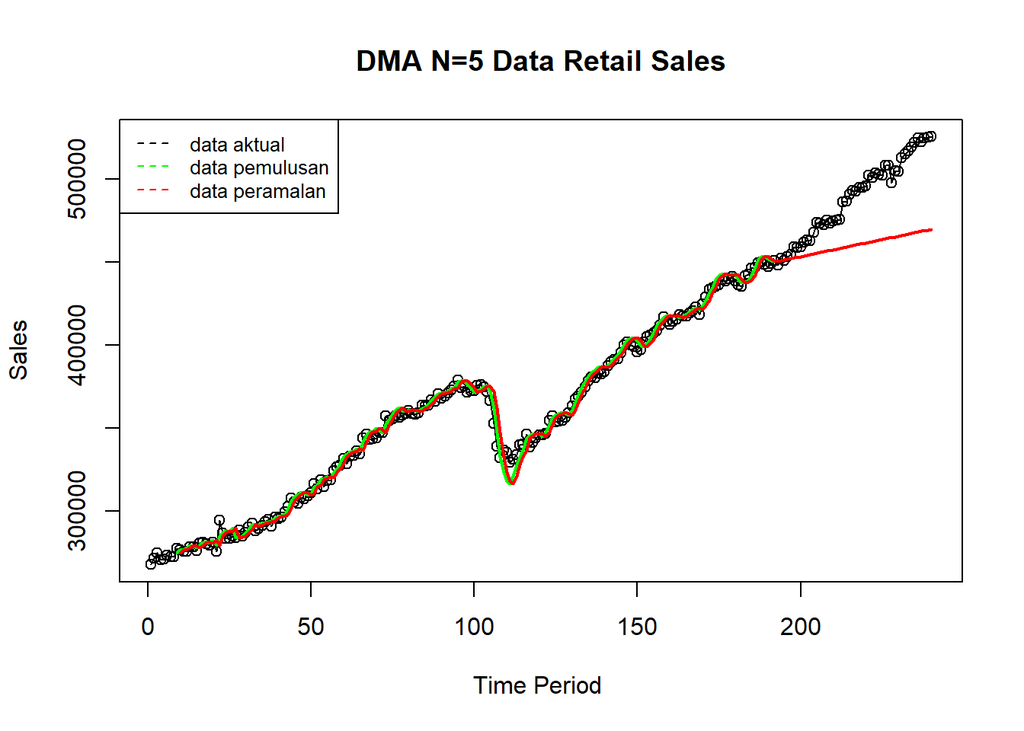

```r
ts.plot(data.ts, xlab="Time Period ", ylab="Sales", main= "DMA N=5 Data Retail Sales")
points(data.ts)
lines(data.gab2[,3],col="green",lwd=2)
lines(data.gab2[,6],col="red",lwd=2)
legend("topleft",c("data aktual","data pemulusan","data peramalan"), lty=8, col=c("black","green","red"), cex=0.8)
```

### I. Menghitung nilai keakuratan data latih

```r
error_train.dma = train_ma.ts-data.ramal2[1:length(train_ma.ts)]
SSE_train.dma = sum(error_train.dma[10:length(train_ma.ts)]^2)
MSE_train.dma = mean(error_train.dma[10:length(train_ma.ts)]^2)
MAPE_train.dma = mean(abs((error_train.dma[10:length(train_ma.ts)]/train_ma.ts[10:length(train_ma.ts)])*100))

akurasi_train.dma <- matrix(c(SSE_train.dma, MSE_train.dma, MAPE_train.dma))
row.names(akurasi_train.dma)<- c("SSE", "MSE", "MAPE")
colnames(akurasi_train.dma) <- c("Akurasi m = 5")
akurasi_train.dma
```

```
##      Akurasi m = 5
## SSE   4.387501e+09
## MSE   2.397541e+07
## MAPE  1.009115e+00
```

Perhitungan akurasi pada data latih menggunakan nilai MAPE menghasilkan nilai MAPE yang kurang dari 2% sehingga dikategorikan sangat baik.

### II. Menghitung nilai keakuratan data uji

```r
error_test.dma = test_ma.ts-data.gab2[193:240,6]
SSE_test.dma = sum(error_test.dma^2)
MSE_test.dma = mean(error_test.dma^2)
MAPE_test.dma = mean(abs((error_test.dma/test_ma.ts*100)))

akurasi_test.dma <- matrix(c(SSE_test.dma, MSE_test.dma, MAPE_test.dma))
row.names(akurasi_test.dma)<- c("SSE", "MSE", "MAPE")
colnames(akurasi_test.dma) <- c("Akurasi m = 5")
akurasi_test.dma
```

```
##      Akurasi m = 5
## SSE   5.482403e+10
## MSE   1.142167e+09
## MAPE  5.723298e+00
```

Perhitungan akurasi menggunakan data uji menghasilkan nilai MAPE yang kurang dari 10% sehingga nilai akurasi ini dapat dikategorikan sebagai sangat baik.

### Perbandingan pemulusan SMA dan DMA

Jika dibandingkan antara metode SMA dan DMA, data latih dan data uji pada metode DMA lebih baik digunakan dibandingkan metode SMA pada data berpola trend.